# GSW Matchup Analysis

Jiwhan Son

7/4/2020

We’re going to do some analysis for a matchup against the Golden State Warriors. I’m using a dataset from Kaggle that lists all shots from the field(free throws not included) during the 2014-2015 season.

# Importing Data

As before, we’re going to import our dataset in the same way. After, we’re going to filter the data to only include shots from games that GSW played in.

```r
shot_logs <- read_csv("C:/Users/jiwha/Desktop/NBA Project/shot_logs.csv",
                      col_types = cols(LOCATION = col_factor(levels = c("H", "A")),
                                       W = col_factor(levels = c("W", "L")),
                                       SHOT_RESULT = col_factor(levels = c("made", "missed")),
                                       PTS_TYPE = col_factor(levels = c(3, 2))))
GSW_games <- shot_logs %>%
  filter(grepl("GSW", MATCHUP) == TRUE)
```

# Home Field Advantage

In the NBA, many players considered the Oakland Arena one of the hardest places to play at due to the loyalty of the Warrior’s fan base. Is there any truth to this? Let’s find out.

Let’s look at GSW’s FG% per game, separated by home vs. away games

```r
GSW_shots <- GSW_games %>%
  filter((grepl("GSW vs.", MATCHUP) == TRUE & LOCATION == "H") | (grepl("GSW @", MATCHUP) == TRUE & LOCATION == "A"))

GSW_home_away <- GSW_shots %>%
  group_by(MATCHUP, LOCATION) %>%
  summarize(FGPERC = mean(FGM))
```

Now visualize this data into a box plot

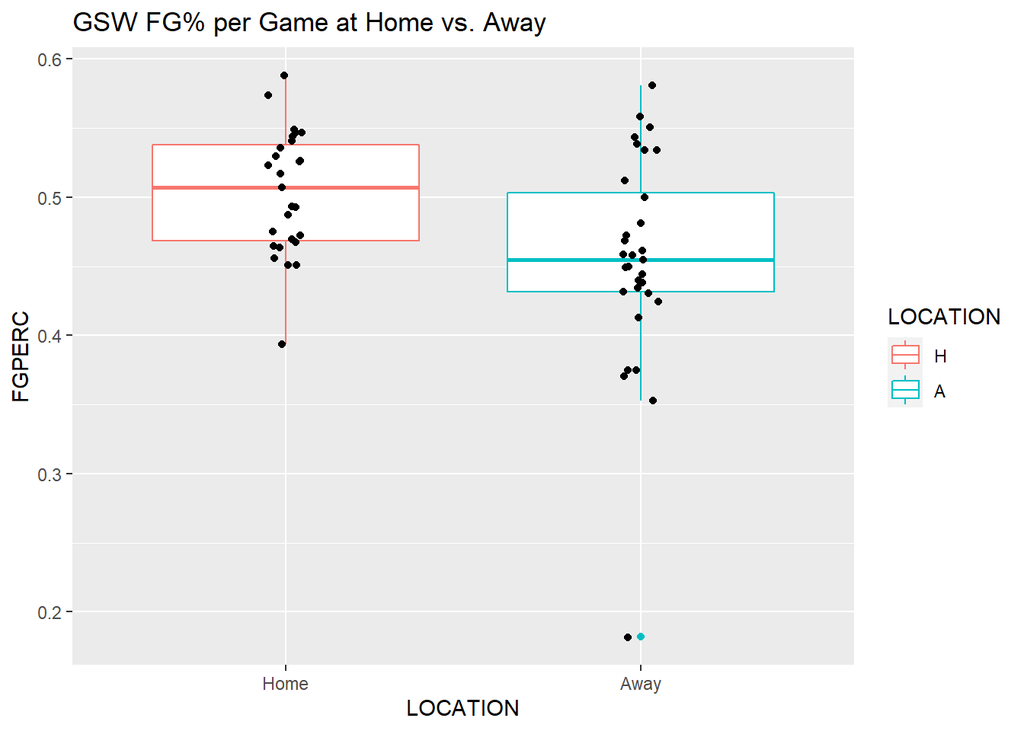

```r
plot_GSW_home_away <- ggplot(data = GSW_home_away, aes(x = LOCATION, y = FGPERC)) +
  geom_boxplot(aes(color = LOCATION))+
  geom_jitter(width = 0.05) +
  ggtitle("GSW FG% per Game at Home vs. Away") +
  scale_x_discrete(labels = c("H" = "Home", "A" = "Away"))
plot_GSW_home_away
```

Should we look at it the other way? Let’s look at opposing teams FG% by game vs GSW, again separated by Home vs. Away

```r
vs_GSW_shots <- GSW_games %>%
  filter(!((grepl("GSW vs.", MATCHUP) == TRUE & LOCATION == "H") | (grepl("GSW @", MATCHUP) == TRUE & LOCATION == "A")))

vs_GSW_home_away <- vs_GSW_shots %>%
  group_by(MATCHUP, LOCATION) %>%
  summarize(FGPERC = mean(FGM))
```

Again, visualize this data into a box plot

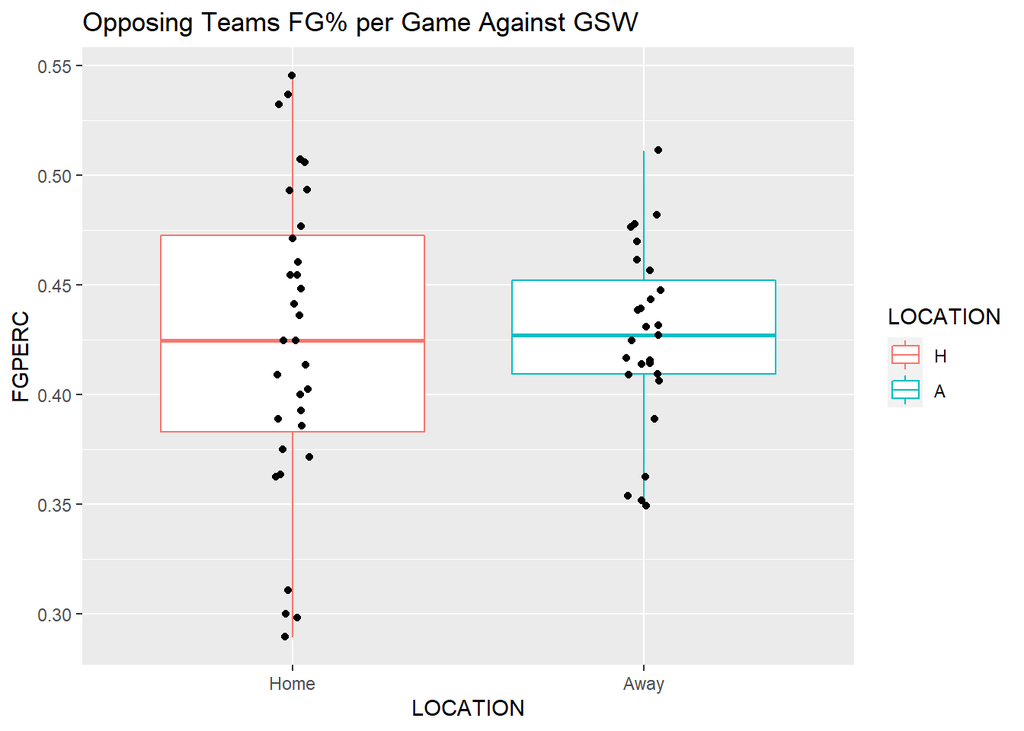

```r
plot_vs_GSW_home_away <- ggplot(data = vs_GSW_home_away, aes(x = LOCATION, y = FGPERC)) +
  geom_boxplot(aes(color = LOCATION)) +
  geom_jitter(width = 0.05) +
  ggtitle("Opposing Teams FG% per Game Against GSW") +
  scale_x_discrete(labels = c("H" = "Home", "A" = "Away"))
plot_vs_GSW_home_away
```

Interesting. From our plots, we can see that GSW does seem to shoot better at Oakland Arena(home) than they do at opposing team’s arenas. For teams playing against GSW, there appears to be more consistent performances at Oakland Arena.

# Stopping Klay Thompson

Stop Klay??? IMPOSSIBLE!!! But…can we use our data to maybe figure some stuff out? Let’s try.

## Examination of Klay’s shots

Let’s check out a distribution of his shots by distance

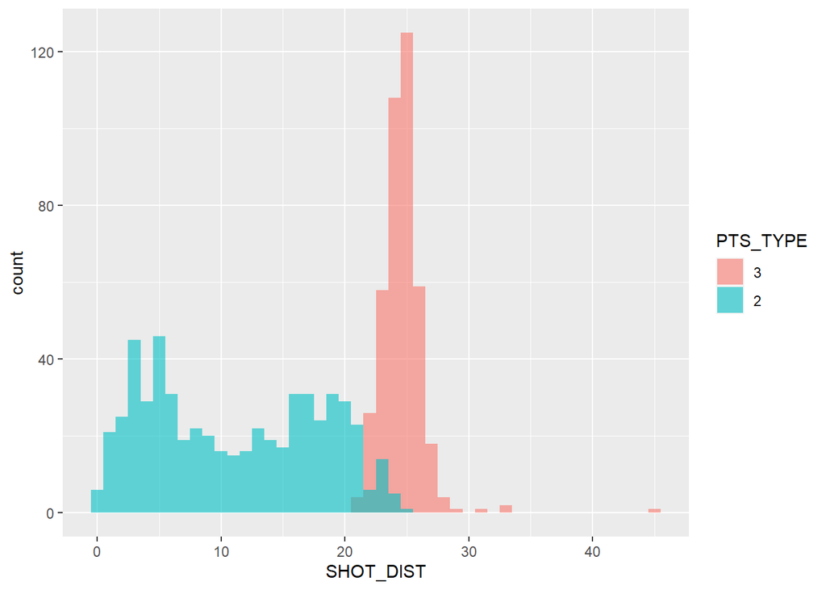

```r
klay_shots <- shot_logs %>%
  filter(player_name == "klay thompson")

klay_shot_dist <- ggplot(data = klay_shots, aes(x = SHOT_DIST, fill = PTS_TYPE)) +
  geom_histogram(binwidth = 1, position = "identity", alpha = 0.6)
klay_shot_dist
```

We can see we have 2 peaks for Klay’s 2 PT shot as well as a significant peak for his 3PT shot.

Let’s see if we can get anything from his split and misses. We’ll use proportions here as well to get a better picture.

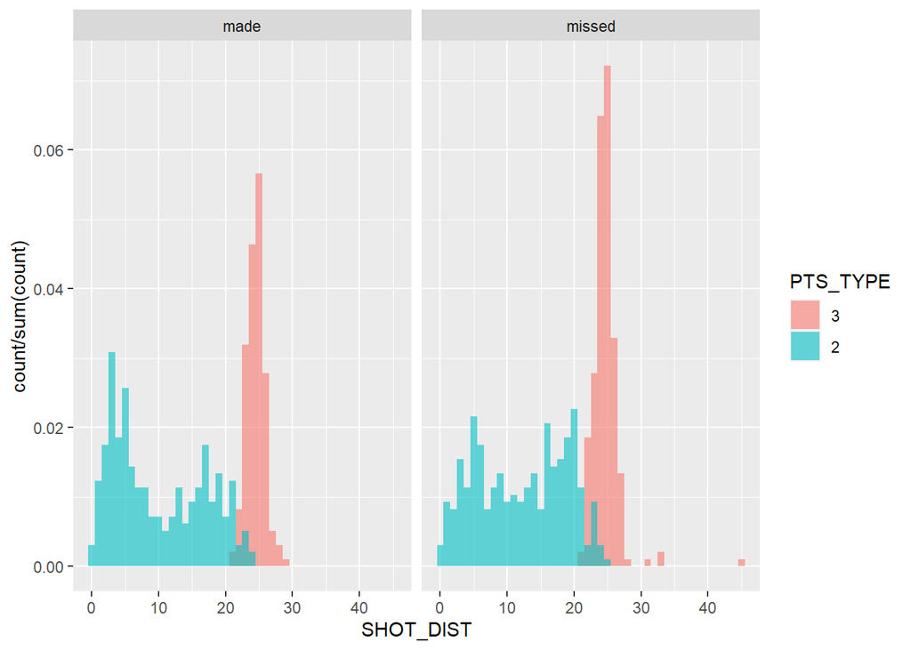

```r
klay_shot_dist2 <- ggplot(data = klay_shots, aes(x = SHOT_DIST, fill = PTS_TYPE)) +
  geom_histogram(aes(y = stat(count / sum(count))), binwidth = 1, position = "identity", alpha = 0.6) +
  facet_wrap(~ SHOT_RESULT)
klay_shot_dist2
```

Nothing too sure from here, there seems to be a spot around 10ft where he seems to miss more than make. Let’s take a closer look at his 2Pt shot to explore this more.

I want to calculate the % chance of making a shot based on shot distance. Here, I’m going to extract Klay’s 2PT shots and round the distance to the nearest ft.

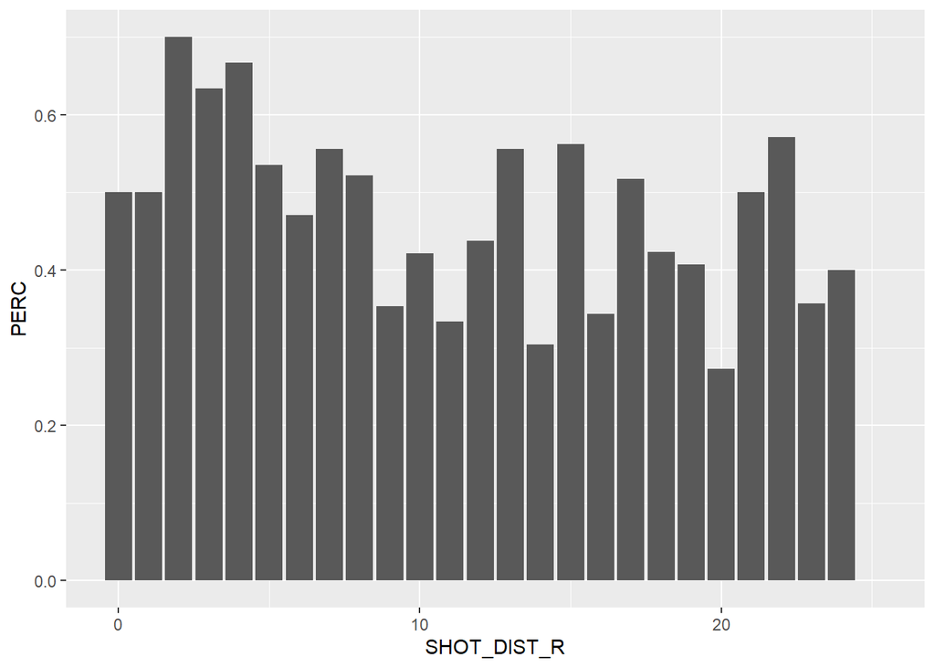

```r
klay_2pt <- klay_shots %>%
  filter(PTS_TYPE == 2) %>%
  select(SHOT_DIST, SHOT_RESULT, FGM) %>%
  mutate(SHOT_DIST_R = round(SHOT_DIST))

klay_2pt_chance <- klay_2pt %>%
  group_by(SHOT_DIST_R) %>%
  summarize(PERC = mean(FGM)) %>%
  arrange(SHOT_DIST_R)

klay_2pt_perc <- ggplot(data = klay_2pt_chance, aes(x = SHOT_DIST_R, y = PERC)) +
  geom_col()
klay_2pt_perc
```

Let’s make this more useful. I want to highlight the shot distances that correspond to the bottom third of his 2 PT%.

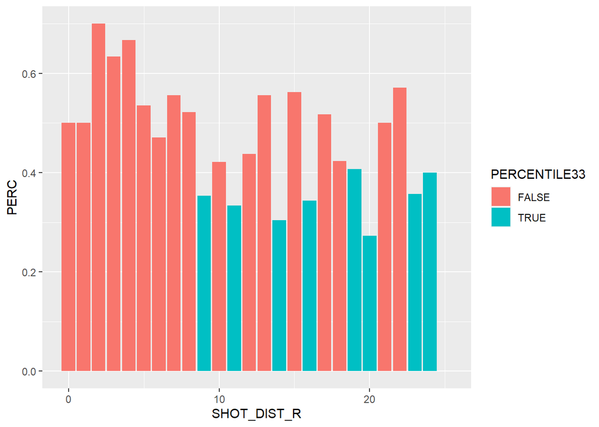

```r
klay_2pt_chance <- klay_2pt_chance %>%
  mutate(PERCENTILE33 = ifelse(PERC <= quantile(klay_2pt_chance$PERC, 0.33), TRUE, FALSE))

klay_2pt_perc2 <- ggplot(data = klay_2pt_chance, aes(x = SHOT_DIST_R, y = PERC, fill = PERCENTILE33)) +
  geom_col()
klay_2pt_perc2
```

This gives us a better picture. We can see the shot distances where Klay’s FG% is lower. **We have nice pockets at 19-20ft and 23-24ft where a defender can push Klay to reduce his chances of making a basket.**

Now let’s look at his shooting behavior

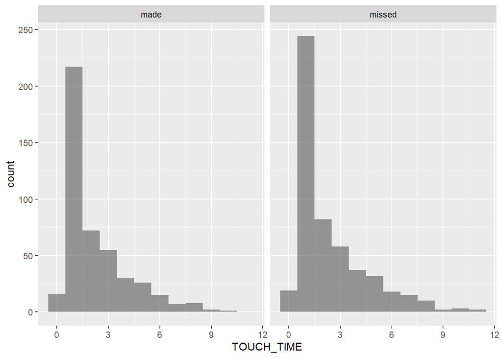

```r
klay_touch_dist <- ggplot(data = klay_shots, aes(x = TOUCH_TIME)) +
  geom_histogram(binwidth = 1, position = "identity", alpha = 0.6) +
  facet_wrap(~ SHOT_RESULT)
klay_touch_dist
```

We can see Klay’s high use of a Catch & Shoot 3 with a majority of his 3 shots having a touch time of less than 2 seconds. **This is a player that we don’t want to leave open at all and follow him closely even when he isn’t holding the ball.**

## HOU vs. GSW

Now we have some light approaches to defending Klay, let’s see if we have some preferential defensive matchups against him. Let’s say I’m the Houston Rockets, the 2nd Seed in the Western Conference right behind GSW.

Since we already showed his high volume 3 shooting, let’s examine that a bit more. We’re going to try and defend against Klay’s 3 shot. Let’s try to figure out our best defenders for this.

```r
klay_3pt_matchup <- klay_shots %>%
  filter(PTS_TYPE == 3) %>%
  select(MATCHUP, CLOSEST_DEFENDER, SHOT_RESULT, FGM)

klay_3pt_matchup_HOU <- klay_3pt_matchup %>%
  filter(grepl("HOU", MATCHUP) == TRUE) %>%
  add_count(CLOSEST_DEFENDER) %>%
  group_by(CLOSEST_DEFENDER) %>%
  summarize(PT3PERC = mean(FGM), TOTAL_3_CONTEST = mean(n)) %>%
  arrange(PT3PERC)
klay_3pt_matchup_HOU
```

```
## # A tibble: 8 x 3
##   CLOSEST_DEFENDER    PT3PERC TOTAL_3_CONTEST
##   <chr>                 <dbl>           <dbl>
## 1 Beverley, Patrick     0                   2
## 2 Canaan, Isaiah        0                   2
## 3 Dorsey, Joey          0                   1
## 4 Ariza, Trevor         0.125               8
## 5 Harden, James         0.25                8
## 6 Terry, Jason          0.333               3
## 7 Brewer, Corey         1                   1
## 8 Motiejunas, Donatas   1                   2
```

We have a ranked list of Defenders vs. Klay’s 3PT%. We also have a total contested column just for extra consideration.

Let’s go ahead and display this with a horizontal line showing his overall 3PT%

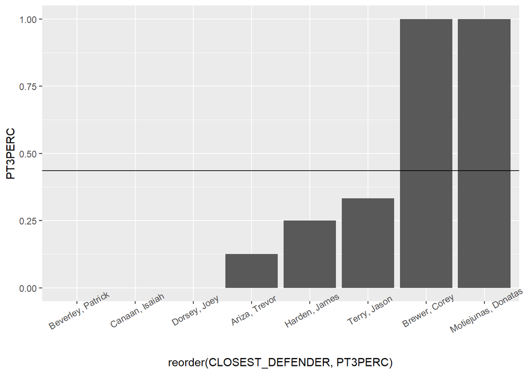

```r
klay_3pt_matchup_plot <- ggplot(data = klay_3pt_matchup_HOU, aes(x = reorder(CLOSEST_DEFENDER, PT3PERC), y = PT3PERC)) +
  geom_col() +
  theme(axis.text.x = element_text(angle = 30)) +
  geom_hline(aes(yintercept = mean(klay_3pt_matchup$FGM)))
klay_3pt_matchup_plot
```

**Patrick Beverly, Isaiah Canaan, and Joey Dorsey were all able to successfully defend against all Klay 3s. However, they only defended against 2, 2, and 1 3PT respectively. Trevor Ariza and James Harden defended against 8 3PTs each and were both successful in keeping him under his overall 3PT%.** So it looks like we were able to identify some preferential defensive matchups against the Klay 3.

Should we try this against his 2 shot as well? Let’s do that.

```r
klay_2pt_matchup <- klay_shots %>%
  filter(PTS_TYPE == 2) %>%
  select(MATCHUP, CLOSEST_DEFENDER, SHOT_RESULT, FGM) %>%
  filter(grepl("HOU", MATCHUP) == TRUE) %>%
  add_count(CLOSEST_DEFENDER) %>%
  group_by(CLOSEST_DEFENDER) %>%
  summarize(PT2PERC = mean(FGM), TOTAL_2_CONTEST = mean(n)) %>%
  arrange(PT2PERC)
klay_2pt_matchup
```

```
## # A tibble: 11 x 3
##    CLOSEST_DEFENDER     PT2PERC TOTAL_2_CONTEST
##    <chr>                  <dbl>           <dbl>
##  1 Brewer, Corey          0                   1
##  2 Dorsey, Joey           0                   1
##  3 Johnson, Nick          0                   1
##  4 Terry, Jason           0.25                4
##  5 Black, Tarik           0.5                 4
##  6 Harden, James          0.5                12
##  7 Motiejunas, Donatas    0.571               7
##  8 Papanikolaou, Kostas   0.667               3
##  9 Smith, Josh            0.667               3
## 10 Ariza, Trevor          0.75                4
## 11 Beverley, Patrick      1                   3
```

Again, we have a ranked list of Defenders vs. Klay’s 2PT%. The top 3 defenders held him to 0% but they only defended 1 shot each.

Let’s just go ahead and filter them out since a sample size of 1 isn’t to helpful. Then we’ll make a visualization again.

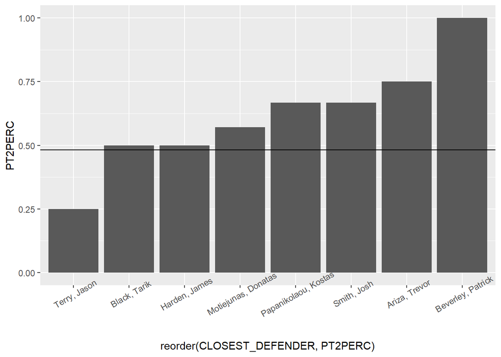

```r
klay_2pt_matchup <- klay_2pt_matchup %>%
  filter(TOTAL_2_CONTEST > 1)

klay_2pt_matchup_plot <- ggplot(data = klay_2pt_matchup, aes(x = reorder(CLOSEST_DEFENDER, PT2PERC), y = PT2PERC)) +
  geom_col() +
  theme(axis.text.x = element_text(angle = 30)) +
  geom_hline(aes(yintercept = mean(klay_2pt$FGM)))
klay_2pt_matchup_plot
```

**Looks like Jason Terry was the only defender successful in keeping Klay under his overall 2PT%. James Harden and Donatas Motiejunas were close and guarded the most shots at 12 and 7 respectively so we’ll give them some credit there.**

Looks like we have some tools to defend against GSW. Of course, none of this would have helped as the Golden State Warriors met the Houston Rockets in the Western Conference Finals winning the series 4-1. They would go on to win the finals 4-2 against the Cleveland Caveliers.

Like I said before…this was an impossible task.